# Session 3

Sample Size Estimation

Matt Denwood

2023-07-13

# Background to sample size calculations

## Power calculation

Power is defined as the proportion of experiments that can be expected to give p-values of <= 0.05 (or whatever alpha is chosen), conditional on the specified parameters. Power calculations can be done using:

- Approximation methods, e.g. power.t.test:

```r
power.t.test(n = 150, delta = 0.25, sd = 1)
```

```
##
##      Two-sample t test power calculation
##
##               n = 150
##           delta = 0.25
##              sd = 1
##       sig.level = 0.05
##           power = 0.5785239
##     alternative = two.sided
##
## NOTE: n is number in *each* group
```

- Numerical methods i.e. by simulation:

```r
library("tidyverse")
```

A function to simulate data, then calculate and return a p-value:

```r
p_fun <- function(parameters){
  sample1 <- rnorm(parameters$Size, mean=0, sd=1)
  sample2 <- rnorm(parameters$Size, mean=0.25, sd=1)
  parameters |>
    mutate(P_val = t.test(sample1, sample2)$p.value)
}
```

There is randomness so this will be different every time it is run:

```r
p_fun(tibble(Size = 150L))
```

```
## # A tibble: 1 × 2
##    Size  P_val
##   <int>  <dbl>
## 1   150 0.0171
```

```r
p_fun(tibble(Size = 150L))
```

```
## # A tibble: 1 × 2
##    Size  P_val
##   <int>  <dbl>
## 1   150 0.0109
```

So we must run it several times (e.g. 1000):

```r
tibble(Iteration = seq_len(1000L), Size = 150L) |>
  group_split(Iteration, Size) |>
  lapply(p_fun) |>
  bind_rows() ->
  pvals
```

And we calculate the power as so:

```r
pvals |>
  group_by(Size) |>
  summarise(Power = sum(P_val <= 0.05) / n(), .groups="drop")
```

```
## # A tibble: 1 × 2
##    Size Power
##   <int> <dbl>
## 1   150 0.581
```

### Exercise

1. Examine and run the code given above - make sure you understand what the p_fun function does and why the code is separated into function/usage like this
2. What are the advantages/disadvantages of each approach?

## Sample size estimation

The goal is typically to find the minimum sample size that corresponds to >= 80% power, for a specified set of parameters. This can be done in one of two ways:

- Using approximation methods directly i.e.:

```r
power.t.test(n = NULL, delta = 0.25, sd = 1, power = 0.8)
```

```
##
##      Two-sample t test power calculation
##
##               n = 252.1281
##           delta = 0.25
##              sd = 1
##       sig.level = 0.05
##           power = 0.8
##     alternative = two.sided
##
## NOTE: n is number in *each* group
```

- By trying different sample sizes (using either approximation methods or simulation):

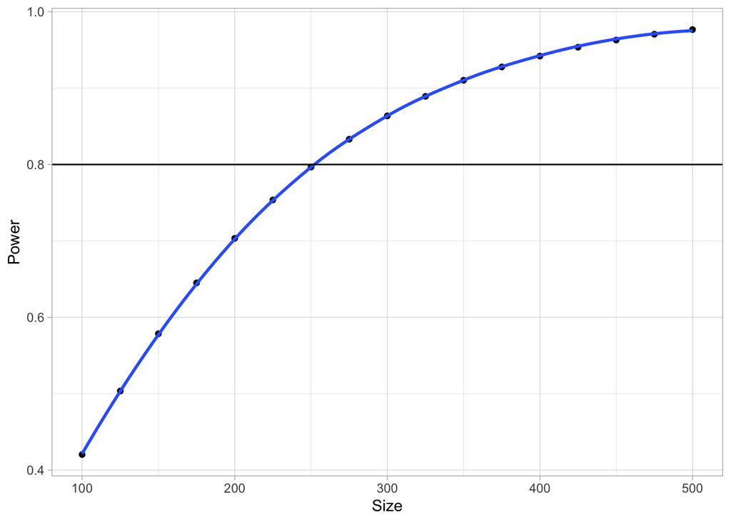

```r
tibble(Size = seq(100, 500, by=25)) |>
  group_split(Size) |>
  lapply(function(parameters){
    parameters |>
      mutate(Power = power.t.test(n = parameters$Size, delta = 0.25, sd = 1)$power)
  }) |>
  bind_rows() |>
  ggplot(aes(x=Size, y=Power)) +
  geom_point() +
  stat_smooth(method="loess") +
  geom_hline(yintercept = 0.8)
## `geom_smooth()` using formula = 'y ~ x'
```

### Exercise

1. Find the required sample size by simulation
2. What are the challenges of doing this by simulation that we don’t have to worry about when using approximation methods?

# Sample size calculation for LCM

## Determining the objective

Let’s take a simple 2-test, 2-population Hui-Walter model as an example.

Group discussion:

- What parameters do we need to simulate a dataset? Which of these are experimental/controllable parameters, and which are nuisance parameters?
- What might we be interested in estimating from the model?
- How can we maximise the efficiency of fitting the model to each dataset we simulate?

### Exercise

Write a function to:

1. Take input parameters: 2xN, 2xSe, 2xSp, 2xPrev
2. Simulate a dataset
3. Analyse the dataset as quickly as possible
4. Return 95% CI for the two prevalence, sensitivity and specificity parameters

Remember efficiency, including:

- Restrict Se/Sp to values above 50%
- Run minimal burnin and samples
- Don’t calculate plots or summary statistics you don’t need i.e. set summarise=FALSE
- Set the following to silence output:

```r
runjags.options(silent.jags=TRUE, silent.runjags=TRUE)
```

Finally, test that the function works. Use parameter values for prevalence, se and sp as follows:

- Prevalence: 10%, 35%
- Sensitivity: 80%, 90%
- Specificity: 99%, 95%

Use your own suggestions for N values!

### Optional exercise

Adapt the function to calculate and return 95% CI for the following:

- The difference in prevalence between the two populations
- Youden’s index for each test (Se+Sp-1)
- The ratio of Youden’s index between each test

## Obtaining an answer

The answer depends on the objective … and there are many things that might be the objective, including:

- Width of 95% CI for sensitivity for one or both tests
- Width of 95% CI for specificity for one or both tests
- Width of 95% CI for prevalence in one or both populations
- Something more complex, like proving one test has a higher Se/Sp than the other (maybe using Bayesian p-values)
- Several / all of the above

Group discussion:

- How would we expect these things to vary depending on:
  - Number of samples in each population
  - Estimated prevalence in each population
- What trade-offs can we expect?

### Exercise

1. Copy/modify your function to calculate and return three values: the width of 95% CI for the two prevalence parameters, and the average of these widths
2. Calculate and analyse 50 datasets each for a total of 120, 150, 240 samples, where the samples are split 1/3 vs 2/3, 1/2 vs 1/2, and 2/3 vs 1/3 between the two populations.
3. Visualise the results

Tip: use pbapply::pblapply to get a progress indicator and/or split the computation onto multiple processors.

## Additional considerations

## More reading

If you are interested, you can see some related work here: https://www.costmodds.org/projects/covetlabLCM/sample_size_calculation.html